# Dragon Ball Supervised Learning Classification

## Problem Definition

Can we accurately predict whether a Dragon Ball character will win or lose a fight based on their attributes such as Power Level, Race, Transformations, Techniques, and Previous Battles?

### Context

- In the Dragon Ball universe, battles are determined by various factors, including a fighter’s power level, race, transformations, fighting techniques, and experience.
- Using machine learning classification models, we can estimate the probability of winning based on these attributes.
- This could be useful for game balancing, AI-driven character matchups, competitive strategy analysis, and fan discussions.

### Objective

- Develop a classification model to predict whether a character will win or lose a battle.
- Identify key features that contribute the most to battle outcomes.
- Compare the performance of different models (Logistic Regression, Random Forest, XGBoost, and SVM) to determine the best approach.
- Analyze how race, transformations, and fighting styles impact battle success.

## Importing Libraries and the Dataset

```python
# Mounting the drive
from google.colab import drive
drive.mount('/content/drive')
```

```python
# Used to ignore the warning given as output of the code
import warnings                                       # Ignore the warning given as output of the code
warnings.filterwarnings('ignore')

# Basic libraries of python for numeric and dataframe computations
import numpy as np                                    # Basic libraries numeric and dataframe computations
import pandas as pd

# Import Matplotlib the Basic library for data visualization
# Import seaborn - Slightly advanced library for data visualization
import matplotlib.pyplot as plt                       # Basic visualization library
import seaborn as sns

# Import the required library to compute the cosine similarity between two vectors


# Import defaultdict from collections A dictionary output that does not raise a key error
from collections import defaultdict                   # A dictionary output that does not raise a key error
```

## Load the Dataset

```python
# Loading the ratings dataset
data = pd.read_csv('/content/drive/MyDrive/My DS DA/Dragon Ball Z/data.csv')
```

## Data Overview

```python
data.sample(5)
```

|  | Name | Race | Gender | Power Level | Ki Blast | Melee Combat | Speed | Special Attack | Transformation | Speed_Original | Normalized_Power | Power_Score | Meta |
| --- | --- | --- | --- | --- | --- | --- | --- | --- | --- | --- | --- | --- | --- |
| 63 | Upa | Human | Male | 10 | NaN | Martial Arts | 1 | NaN | - | Slow | 0.00 | 0.30 | Upa Human nan Martial Arts nan - Male |
| 47 | Yakon | Demon | Male | 8000 | Darkness Eye Beam | Darkness Slash | 3 | NaN | Absorption | Fast | 0.04 | 0.93 | Yakon Demon Darkness Eye Beam Darkness Slash n... |
| 1 | Vegeta | Saiyan | Male | 8500 | Galick Gun | Big Bang | 3 | Final Flash | Super Saiyan | Fast | 0.04 | 0.93 | Vegeta Saiyan Galick Gun Big Bang Final Flash ... |
| 46 | Babidi | Wizard | Male | 2000 | Mind Control | Babidi Curse | 1 | NaN | - | Slow | 0.01 | 0.31 | Babidi Wizard Mind Control Babidi Curse nan - ... |
| 40 | Recoome | Alien | Male | 40000 | Recoome Eraser Gun | Recoome Kick | 3 | Recoome Ultra Fighting Bomber | Transformation | Fast | 0.20 | 1.04 | Recoome Alien Recoome Eraser Gun Recoome Kick ... |

Check for missing values

```python
data.isnull().sum()
```

|  | 0 |
| --- | --- |
| Name | 0 |
| Race | 0 |
| Gender | 0 |
| Power Level | 0 |
| Ki Blast | 20 |
| Melee Combat | 11 |
| Speed | 0 |
| Special Attack | 31 |
| Transformation | 0 |
| Speed_Original | 0 |
| Normalized_Power | 0 |
| Power_Score | 0 |
| Meta | 0 |

**dtype:** int64

```python
(data.isnull().sum() / data.shape[0])*100
```

|  | 0 |
| --- | --- |
| Name | 0.000000 |
| Race | 0.000000 |
| Gender | 0.000000 |
| Power Level | 0.000000 |
| Ki Blast | 29.411765 |
| Melee Combat | 16.176471 |
| Speed | 0.000000 |
| Special Attack | 45.588235 |
| Transformation | 0.000000 |
| Speed_Original | 0.000000 |
| Normalized_Power | 0.000000 |
| Power_Score | 0.000000 |
| Meta | 0.000000 |

**dtype:** float64

- mising values in columns are less than 50% and some values may be because characters do not have abilities or transformations.

Check for duplicated rows

```python
data.duplicated().sum()
```

```
0
```

```python
data.info()
```

```
<class 'pandas.core.frame.DataFrame'>
RangeIndex: 68 entries, 0 to 67
Data columns (total 13 columns):
 #   Column            Non-Null Count  Dtype
---  ------            --------------  -----
 0   Name              68 non-null     object
 1   Race              68 non-null     object
 2   Gender            68 non-null     object
 3   Power Level       68 non-null     int64
 4   Ki Blast          48 non-null     object
 5   Melee Combat      57 non-null     object
 6   Speed             68 non-null     int64
 7   Special Attack    37 non-null     object
 8   Transformation    68 non-null     object
 9   Speed_Original    68 non-null     object
 10  Normalized_Power  68 non-null     float64
 11  Power_Score       68 non-null     float64
 12  Meta              68 non-null     object
dtypes: float64(2), int64(2), object(9)
memory usage: 7.0+ KB
```

Number of unique values in each column

```python
data.nunique()
```

|  | 0 |
| --- | --- |
| Name | 68 |
| Race | 17 |
| Gender | 2 |
| Power Level | 36 |
| Ki Blast | 39 |
| Melee Combat | 40 |
| Speed | 3 |
| Special Attack | 36 |
| Transformation | 11 |
| Speed_Original | 3 |
| Normalized_Power | 15 |
| Power_Score | 20 |
| Meta | 68 |

**dtype:** int64

## Data Preprocessing and Feature Engineering

Dropping COlumns

```python
data = data.drop(['Name', 'Meta', 'Gender', 'Normalized_Power', 'Power_Score', 'Speed_Original'], axis = 1)
data.head()
```

|  | Race | Power Level | Ki Blast | Melee Combat | Speed | Special Attack | Transformation |
| --- | --- | --- | --- | --- | --- | --- | --- |
| 0 | Saiyan | 9000 | Kamehameha | Dragon Fist | 3 | Spirit Bomb | Super Saiyan |
| 1 | Saiyan | 8500 | Galick Gun | Big Bang | 3 | Final Flash | Super Saiyan |
| 2 | Namekian | 8000 | Special Beam Cannon | Namekian Punch | 3 | Hellzone Grenade | Fuse with Kami |
| 3 | Half-Saiyan | 7500 | Masenko | Soaring Dragon Strike | 3 | Father-Son Kamehameha | Super Saiyan 2 |
| 4 | Half-Saiyan | 7800 | Burning Attack | Sword Strike | 3 | Heat Dome Attack | Super Saiyan |

Creating Numerical and Categorical Columns

```python
num_cols = ['Speed']

cat_cols = ['Race', 'Ki Blast', 'Melee Combat', 'Special Attack', 'Transformation']
```

## Exploratory Data Analysis

- [EDA](https://colab.research.google.com/drive/11_RHgukIdfJhYBmV1efLdg5AxEUDSQn3?usp=sharing)
- [Unsupervised Learning](https://colab.research.google.com/drive/1CMT8F7UpDIHC7l4nXKm9RJCF3CKiu9lt?usp=sharing)
- [Supervised Learning Regression EDA](https://colab.research.google.com/drive/1Ajn_UUD0WagAUDcXMLbiUYNrRAXAnSSm?usp=sharing)
- [Supervised Learning Regression with Lasso and Ridge](https://colab.research.google.com/drive/1CxChCQxS-7xTKGTyo1hDvFhqY8ka6Kqm?usp=sharing)

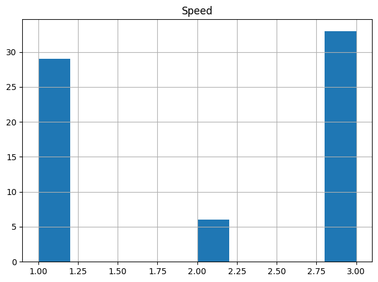

```python
# Creating histograms
data[num_cols].hist()

plt.tight_layout()
```

```python
for i in cat_cols:
    print(data[i].value_counts(normalize = True))

    print('*' * 40)
```

```
Race
Human            0.279412
Android          0.147059
Alien            0.117647
Saiyan           0.102941
Namekian         0.058824
Demon            0.058824
Frost Demon      0.029412
Bio-Android      0.029412
Shape-shifter    0.029412
Half-Saiyan      0.029412
Angel            0.029412
Majin            0.014706
Genie            0.014706
Kai              0.014706
Monkey           0.014706
Grasshopper      0.014706
Wizard           0.014706
Name: proportion, dtype: float64
Ki Blast
Kamehameha              0.062500
S.S. Deadly Bomber      0.062500
Energy Wave             0.062500
Dodon Ray               0.041667
Eye Beam                0.041667
Death Beam              0.041667
Supernova Cooler        0.020833
Eraser Cannon           0.020833
Final Explosion         0.020833
Power Blitz             0.020833
Recoome Eraser Gun      0.020833
Bunkai Teleport         0.020833
Galactic Buster         0.020833
Explosive Demon Wave    0.020833
Spinning Blade          0.020833
Darkness Eye Beam       0.020833
Mind Control            0.020833
Destruction             0.020833
Energy Drain            0.020833
Hell's Flash            0.020833
```

[output cut: 98 more lines]

```
Temporal Do-Over                 0.027027
Name: proportion, dtype: float64
Transformation
-                     0.632353
Transformation        0.147059
Super Saiyan          0.058824
Majin Form            0.044118
Merge with Piccolo    0.029412
Fuse with Kami        0.014706
Super Saiyan 2        0.014706
Perfect Form          0.014706
Final Form            0.014706
Various Forms         0.014706
Absorption            0.014706
Name: proportion, dtype: float64
```

```python
pd.crosstab(data['Race'], 'Win_Loss_Label')
pd.crosstab(data['Transformation'], 'Power Level')
pd.crosstab(data['Ki Blast'], 'Power Level')
pd.crosstab(data['Melee Combat'], 'Power Level')
pd.crosstab(data['Special Attack'], 'Power Level')
```

| col_0 Special Attack | Power Level |
| --- | --- |
| - | 2 |
| Blue Cannonball | 1 |
| Body Change | 1 |
| Break Cannon | 1 |
| Chocolate Beam | 1 |
| Darkness Eye Beam | 1 |
| Dimension Sword | 1 |
| Dodon Ray | 1 |
| Dodoria Launcher | 1 |
| Father-Son Kamehameha | 1 |
| Final Flash | 1 |
| Final Impact | 1 |
| Fireball | 1 |
| Four Witches Technique | 1 |
| Galactic Blow | 1 |
| Guldo Freeze | 1 |
| Heat Dome Attack | 1 |
| Hell's Impact | 1 |
| Hellzone Grenade | 1 |
| Infinity Bullet | 1 |
| MAX Power Kamehameha | 1 |
| Monster Crush | 1 |
| Mouth Energy Wave | 1 |
| Non-Stop Violence | 1 |
| Omega Blaster | 1 |
| Psychic Powers | 1 |
| Recoome Ultra Fighting Bomber | 1 |
| Saiyan Man Pose | 1 |
| Saturday Crush | 1 |
| Solar Flare | 1 |
| Solar Kamehameha | 1 |
| Spirit Bomb | 1 |
| Stone Spit | 1 |
| Supernova | 1 |
| Temporal Do-Over | 1 |
| Wolf Fang Fist | 1 |

```python
# pd.crosstab(data['Race'], data['Transformation'])
# pd.crosstab(data['Ki Blast'], data['Melee Combat'])
# pd.crosstab(data['Special Attack'], data['Transformation'])
```

```python
# The mean of numerical variables grouped by attrition
data.groupby(['Power Level'])[num_cols].mean()
```

| Power Level | Speed |
| --- | --- |
| 5 | 1.500000 |
| 10 | 1.000000 |
| 30 | 1.000000 |
| 50 | 1.000000 |
| 100 | 1.000000 |
| 130 | 1.000000 |
| 300 | 2.000000 |
| 700 | 1.000000 |
| 1000 | 1.000000 |
| 1100 | 2.000000 |
| 1400 | 1.000000 |
| 1500 | 2.000000 |
| 1800 | 2.000000 |
| 2000 | 1.333333 |
| 2200 | 3.000000 |
| 2600 | 3.000000 |
| 3000 | 1.000000 |
| 4000 | 2.250000 |
| 4500 | 3.000000 |
| 5000 | 1.000000 |
| 6500 | 3.000000 |
| 7500 | 3.000000 |
| 7800 | 3.000000 |
| 8000 | 3.000000 |
| 8500 | 3.000000 |
| 9000 | 3.000000 |
| 10000 | 1.500000 |
| 12000 | 3.000000 |
| 15000 | 1.000000 |
| 20000 | 3.000000 |
| 40000 | 2.500000 |
| 42000 | 1.000000 |
| 50000 | 3.000000 |
| 100000 | 3.000000 |
| 120000 | 3.000000 |
| 200000 | 3.000000 |

## Model Building

```python
data.sample(5)
```

|  | Race | Power Level | Ki Blast | Melee Combat | Speed | Special Attack | Transformation |
| --- | --- | --- | --- | --- | --- | --- | --- |
| 22 | Human | 130 | NaN | Martial Arts | 1 | NaN | - |
| 35 | Saiyan | 4000 | Bomber DX | Arm Break | 2 | Break Cannon | - |
| 58 | Android | 3000 | Power Blitz | Android Strikes | 1 | NaN | - |
| 5 | Human | 2000 | Destructo Disc | Kamehameha | 2 | Solar Flare | - |
| 10 | Human | 1500 | Kamehameha | Thunder Shock | 1 | MAX Power Kamehameha | - |

```python
data.info()
```

```
<class 'pandas.core.frame.DataFrame'>
RangeIndex: 68 entries, 0 to 67
Data columns (total 7 columns):
 #   Column          Non-Null Count  Dtype
---  ------          --------------  -----
 0   Race            68 non-null     object
 1   Power Level     68 non-null     int64
 2   Ki Blast        48 non-null     object
 3   Melee Combat    57 non-null     object
 4   Speed           68 non-null     int64
 5   Special Attack  37 non-null     object
 6   Transformation  68 non-null     object
dtypes: int64(2), object(5)
memory usage: 3.8+ KB
```

### Transformation Column

- some transformations are in progression (e.g., Super Saiyan < Super Saiyan 2 < Final Form)

```python
print(data['Race'].unique())
```

```
['Saiyan' 'Namekian' 'Half-Saiyan' 'Human' 'Android' 'Bio-Android'
 'Frost Demon' 'Majin' 'Demon' 'Shape-shifter' 'Genie' 'Kai' 'Monkey'
 'Grasshopper' 'Alien' 'Wizard' 'Angel']
```

```python
print(data['Transformation'].unique())
```

```
['Super Saiyan' 'Fuse with Kami' 'Super Saiyan 2' '-' 'Perfect Form'
 'Final Form' 'Various Forms' 'Majin Form' 'Merge with Piccolo'
 'Transformation' 'Absorption']
```

Define Transformation Levels

```python
# Define ordinal encoding for transformations
transformation_levels = {
    '-': 0,  # No transformation
    'Super Saiyan': 1,
    'Super Saiyan 2': 2,
    'Final Form': 3,
    'Perfect Form': 4,
    'Majin Form': 4,  # Equivalent to Perfect Form in strength
    'Absorption': 5,
    'Merge with Piccolo': 6,
    'Fuse with Kami': 7,
    'Various Forms': 8  # Miscellaneous transformations
}
```

Apply Encoding

```python
# Apply ordinal encoding to the Transformation column
data['Transformation_Level'] = data['Transformation'].map(transformation_levels)
```

Verify Encoding

```python
print(data[['Transformation', 'Transformation_Level']].drop_duplicates())
```

```
        Transformation  Transformation_Level
0         Super Saiyan                   1.0
2       Fuse with Kami                   7.0
3       Super Saiyan 2                   2.0
5                    -                   0.0
13        Perfect Form                   4.0
14          Final Form                   3.0
15       Various Forms                   8.0
17          Majin Form                   4.0
27  Merge with Piccolo                   6.0
36      Transformation                   NaN
47          Absorption                   5.0
```

Handle Missing Transformations

```python
data['Transformation_Level'].isnull().sum()
```

```
10
```

```python
data['Transformation_Level'] = data['Transformation_Level'].fillna(0)  # Assign lowest level for unknowns
```

Drop the Original Column

```python
data.drop(columns=['Transformation'], inplace=True)
data.sample(5)
```

|  | Race | Power Level | Ki Blast | Melee Combat | Speed | Special Attack | Transformation_Level |
| --- | --- | --- | --- | --- | --- | --- | --- |
| 20 | Human | 30 | NaN | Martial Arts | 1 | NaN | 0.0 |
| 67 | Angel | 200000 | Staff Strike | Angelic Martial Arts | 3 | Temporal Do-Over | 0.0 |
| 58 | Android | 3000 | Power Blitz | Android Strikes | 1 | NaN | 0.0 |
| 5 | Human | 2000 | Destructo Disc | Kamehameha | 2 | Solar Flare | 0.0 |
| 34 | Saiyan | 1500 | Double Sunday | Tail Strike | 3 | Saturday Crush | 0.0 |

### Other Encoding of Columns

```python
data = pd.get_dummies(data, columns=['Race', 'Ki Blast', 'Melee Combat', 'Special Attack'], prefix='Race')
```

```python
data.sample(5)
```

|  | Power Level | Speed | Transformation_Level | Race_Alien | Race_Android | Race_Angel | Race_Bio-Android | Race_Demon | Race_Frost Demon | Race_Genie | ... | Race_Recoome Ultra Fighting Bomber | Race_Saiyan Man Pose | Race_Saturday Crush | Race_Solar Flare | Race_Solar Kamehameha | Race_Spirit Bomb | Race_Stone Spit | Race_Supernova | Race_Temporal Do-Over | Race_Wolf Fang Fist |
| --- | --- | --- | --- | --- | --- | --- | --- | --- | --- | --- | --- | --- | --- | --- | --- | --- | --- | --- | --- | --- | --- |
| 41 | 40000 | 1 | 0.0 | True | False | False | False | False | False | False | ... | False | False | False | False | False | False | False | False | False | False |
| 8 | 1400 | 1 | 0.0 | False | False | False | False | False | False | False | ... | False | False | False | False | False | False | False | False | False | False |
| 6 | 2200 | 3 | 0.0 | False | False | False | False | False | False | False | ... | False | False | False | False | False | False | False | False | False | False |
| 48 | 4000 | 3 | 0.0 | True | False | False | False | False | False | False | ... | False | False | False | False | False | False | False | False | False | False |
| 34 | 1500 | 3 | 0.0 | False | False | False | False | False | False | False | ... | False | False | True | False | False | False | False | False | False | False |

5 rows × 135 columns

### Create Win/Loss Column

Generate All Possible Matchups

```python
from itertools import combinations

# Generate all possible matchups
battle_pairs = list(combinations(data.index, 2))

# Create a DataFrame for battles
battle_df = pd.DataFrame(battle_pairs, columns=['Character_1', 'Character_2'])

# Merge attributes from the original dataset for both characters
battle_df = battle_df.merge(data, left_on='Character_1', right_index=True, suffixes=('_1', ''))
battle_df = battle_df.merge(data, left_on='Character_2', right_index=True, suffixes=('_1', '_2'))

# Assign winner based on power level, speed, and transformation level
battle_df['Winner'] = np.where(
    (battle_df['Power Level_1'] > battle_df['Power Level_2']) |
    ((battle_df['Power Level_1'] == battle_df['Power Level_2']) & (battle_df['Speed_1'] > battle_df['Speed_2'])) |
    ((battle_df['Power Level_1'] == battle_df['Power Level_2']) &
     (battle_df['Speed_1'] == battle_df['Speed_2']) &
     (battle_df['Transformation_Level_1'] > battle_df['Transformation_Level_2'])),
    battle_df['Character_1'],  # Character_1 wins
    battle_df['Character_2']   # Character_2 wins
)
```

Calculate Each Character's Win Rate

```python
# Count wins for each character
win_counts = battle_df['Winner'].value_counts().reset_index()
win_counts.columns = ['Character', 'Wins']

# Count total battles for each character
total_battles = pd.concat([battle_df['Character_1'], battle_df['Character_2']]).value_counts().reset_index()
total_battles.columns = ['Character', 'Total_Battles']

# Merge win counts with total battles
win_loss_stats = total_battles.merge(win_counts, on='Character', how='left').fillna(0)

# Compute win rate
win_loss_stats['Win_Rate'] = win_loss_stats['Wins'] / win_loss_stats['Total_Battles']
win_loss_stats.drop(columns=['Wins'], inplace=True)

# Convert win rate into a binary target: 1 if win rate > 0.5, else 0
win_loss_stats['Win_Loss_Label'] = (win_loss_stats['Win_Rate'] > 0.5).astype(int)
```

Merge Datasets

```python
# Merge win/loss stats into original dataset
data = data.merge(win_loss_stats[['Character', 'Win_Loss_Label']], left_index=True, right_on='Character', how='left')

# Drop redundant 'Character' column after merging (if necessary)
data.drop(columns=['Character'], inplace=True)
```

```python
data.sample(5)
```

|  | Power Level | Speed | Transformation_Level | Race_Alien | Race_Android | Race_Angel | Race_Bio-Android | Race_Demon | Race_Frost Demon | Race_Genie | ... | Race_Saiyan Man Pose | Race_Saturday Crush | Race_Solar Flare | Race_Solar Kamehameha | Race_Spirit Bomb | Race_Stone Spit | Race_Supernova | Race_Temporal Do-Over | Race_Wolf Fang Fist | Win_Loss_Label |
| --- | --- | --- | --- | --- | --- | --- | --- | --- | --- | --- | --- | --- | --- | --- | --- | --- | --- | --- | --- | --- | --- |
| 38 | 7500 | 3 | 2.0 | False | False | False | False | False | False | False | ... | False | False | False | False | False | False | False | False | False | 1 |
| 3 | 4000 | 3 | 0.0 | True | False | False | False | False | False | False | ... | False | False | False | False | False | False | False | False | False | 0 |
| 55 | 30 | 1 | 0.0 | False | False | False | False | False | False | False | ... | False | False | False | False | False | False | False | False | False | 0 |
| 47 | 7800 | 3 | 0.0 | False | True | False | False | False | False | False | ... | False | False | False | False | False | False | False | False | False | 1 |
| 45 | 1500 | 1 | 0.0 | False | False | False | False | False | False | False | ... | False | False | False | False | False | False | False | False | False | 0 |

5 rows × 136 columns

```python
data.isnull().sum().sum()
```

```
0
```

```python
data.duplicated().sum()
```

```
3
```

```python
data = data.drop_duplicates()
```

```python
data.duplicated().sum()
```

```
0
```

Separating the independent variables (X) and the dependent variable (Y)

```python
# Separating the target variable and other variables
Y = data['Win_Loss_Label']
X = data.drop(columns = ['Win_Loss_Label']) #target
```

```python
data.columns.to_list()
```

```
['Power Level',
 'Speed',
 'Transformation_Level',
 'Race_Alien',
 'Race_Android',
 'Race_Angel',
 'Race_Bio-Android',
 'Race_Demon',
 'Race_Frost Demon',
 'Race_Genie',
 'Race_Grasshopper',
 'Race_Half-Saiyan',
 'Race_Human',
 'Race_Kai',
 'Race_Majin',
 'Race_Monkey',
 'Race_Namekian',
 'Race_Saiyan',
 'Race_Shape-shifter',
 'Race_Wizard',
 'Race_Blue Hurricane',
 'Race_Bomber DX',
 'Race_Bunkai Teleport',
 'Race_Burning Attack',
 'Race_Darkness Eye Beam',
 'Race_Death Beam',
 'Race_Destruction',
 'Race_Destructo Disc',
 'Race_Dodon Ray',
 'Race_Dodoria Beam',
 'Race_Double Sunday',
 'Race_Elegant Blaster',
 'Race_Energy Blast',
 'Race_Energy Drain',
 'Race_Energy Wave',
 'Race_Eraser Cannon',
 'Race_Evil Flame',
 'Race_Explosive Demon Wave',
 'Race_Eye Beam',
 'Race_Final Explosion',
```

[output cut: 81 more lines]

```
 'Race_Mouth Energy Wave',
 'Race_Non-Stop Violence',
 'Race_Omega Blaster',
 'Race_Psychic Powers',
 'Race_Recoome Ultra Fighting Bomber',
 'Race_Saiyan Man Pose',
 'Race_Saturday Crush',
 'Race_Solar Flare',
 'Race_Solar Kamehameha',
 'Race_Spirit Bomb',
 'Race_Stone Spit',
 'Race_Supernova',
 'Race_Temporal Do-Over',
 'Race_Wolf Fang Fist',
 'Win_Loss_Label']
```

## Scaling

Scaling Options

```python
from sklearn.preprocessing import (
    StandardScaler, MinMaxScaler, RobustScaler, MaxAbsScaler,
    PowerTransformer, QuantileTransformer, Normalizer
)

# 📌 Load dataset (Modify path if needed)
#file_path = "your_dataset.csv"  # Update with correct file
#data = pd.read_csv(file_path)

# 📌 Select numeric columns only
numeric_features = data.select_dtypes(include=['number']).dropna()

# 📌 Detect Outliers using IQR (Interquartile Range)
def detect_outliers(df):
    outlier_info = {}
    for column in df.columns:
        Q1 = df[column].quantile(0.25)
        Q3 = df[column].quantile(0.75)
        IQR = Q3 - Q1
        lower_bound = Q1 - 1.5 * IQR
        upper_bound = Q3 + 1.5 * IQR

        # Count outliers
        outlier_count = ((df[column] < lower_bound) | (df[column] > upper_bound)).sum()
        outlier_info[column] = outlier_count

    return outlier_info

outliers = detect_outliers(numeric_features)
outlier_df = pd.DataFrame.from_dict(outliers, orient='index', columns=['Outlier Count'])

# 📌 Check Skewness (to determine if transformation is needed)
skewness = numeric_features.skew()

# 📌 Scaling Options with All Variants
scalers = {
    "StandardScaler": StandardScaler(),
    "MinMaxScaler": MinMaxScaler(),
    "RobustScaler": RobustScaler(),
    "MaxAbsScaler": MaxAbsScaler(),
    "PowerTransformer (Yeo-Johnson)": PowerTransformer(method="yeo-johnson"),
    "PowerTransformer (Box-Cox)": PowerTransformer(method="box-cox"),
    "QuantileTransformer (Normal)": QuantileTransformer(output_distribution="normal"),
    "QuantileTransformer (Uniform)": QuantileTransformer(output_distribution="uniform"),
    "Normalizer (L1)": Normalizer(norm="l1"),
    "Normalizer (L2)": Normalizer(norm="l2"),
    "Normalizer (Max)": Normalizer(norm="max"),
}

scaler_results = {}

# 📌 Try all scalers & transformations
for scaler_name, scaler in scalers.items():
    try:
        transformed_data = scaler.fit_transform(numeric_features)
        transformed_df = pd.DataFrame(transformed_data, columns=numeric_features.columns, index=numeric_features.index)

        # Calculate variance after scaling (Higher is better)
        cumulative_variance = transformed_df.var().sum()
        scaler_results[scaler_name] = cumulative_variance

    except Exception as e:
        print(f"❌ Error with {scaler_name}: {e}")

# 📌 Convert results to DataFrame and Rank
scaler_rank_df = pd.DataFrame(list(scaler_results.items()), columns=['Scaler', 'Cumulative Variance'])
scaler_rank_df = scaler_rank_df.sort_values(by="Cumulative Variance", ascending=False)

# 📌 Pick the best scaler based on variance ranking
best_scaler_name = scaler_rank_df.iloc[0]["Scaler"]
best_scaler = scalers[best_scaler_name]
scaled_data = best_scaler.fit_transform(numeric_features)

# 📌 Convert Scaled Data to DataFrame
scaled_df = pd.DataFrame(scaled_data, columns=numeric_features.columns, index=numeric_features.index)

# 📌 Save the scaled dataset
scaled_df.to_csv("scaled_dataset.csv", index=False)

# 📌 Explain Selection
explanations = {
    "MinMaxScaler": "Scales data between [0,1]. Used in Unsupervised Learning & Deep Learning but NOT recommended for outliers.",
    "StandardScaler": "Standardizes data to mean=0, variance=1. Recommended for Unsupervised Learning & Deep Learning. Works well with outliers.",
    "RobustScaler": "Uses median and IQR. Best choice for handling outliers in both Unsupervised and Supervised Learning.",
    "MaxAbsScaler": "Scales data between [-1,1]. Used for sparse data, not generally needed for typical datasets.",
    "PowerTransformer (Yeo-Johnson)": "Transforms data to be more Gaussian-like. Good for skewed data in Regression & Classification.",
    "PowerTransformer (Box-Cox)": "Similar to Yeo-Johnson but works only with strictly positive values. Reduces skewness.",
    "QuantileTransformer (Normal)": "Maps data to a normal distribution. Works well when distribution is unknown.",
    "QuantileTransformer (Uniform)": "Maps data to a uniform distribution. Useful for highly irregular distributions.",
    "Normalizer (L1)": "Normalizes each row by L1 norm. Good for text-based or sparse datasets.",
    "Normalizer (L2)": "Normalizes each row by L2 norm. Often used in clustering tasks.",
    "Normalizer (Max)": "Normalizes each row by its maximum absolute value. Good for text and sparse data."
}

# 📌 Print Summary
print("\n📊 Scaler Rankings:")
print(scaler_rank_df)

print(f"\n🏆 Best Scaler Chosen: {best_scaler_name}")
print(f"📌 Reason: {explanations.get(best_scaler_name, 'No explanation available')}")

# 📌 Print Insights
if outlier_df['Outlier Count'].sum() > 0:
    print("\n⚠️ Outliers detected! **RobustScaler** is recommended if handling them is critical.")
else:
    print("\n✅ No significant outliers detected. **StandardScaler** is the default recommendation.")

if any(abs(skewness) > 1):
    print("\n⚠️ Skewed data detected! **PowerTransformer**")
```

```
❌ Error with PowerTransformer (Box-Cox): The Box-Cox transformation can only be applied to strictly positive data

📊 Scaler Rankings:
                           Scaler  Cumulative Variance
5    QuantileTransformer (Normal)            63.900626
2                    RobustScaler            23.551879
4  PowerTransformer (Yeo-Johnson)             4.062500
0                  StandardScaler             4.062500
6   QuantileTransformer (Uniform)             0.716766
1                    MinMaxScaler             0.580841
3                    MaxAbsScaler             0.453101
9                Normalizer (Max)             0.007455
7                 Normalizer (L1)             0.007213
8                 Normalizer (L2)             0.006292

🏆 Best Scaler Chosen: QuantileTransformer (Normal)
📌 Reason: Maps data to a normal distribution. Works well when distribution is unknown.

⚠️ Outliers detected! **RobustScaler** is recommended if handling them is critical.

⚠️ Skewed data detected! **PowerTransformer**
```

MinMaxScaler

- Data with a fixed range (0 to 1)
- Does not handle outliers

RobustScaler

- Data with outliers & skewed distributions
- Handles skew and outliers well

QuantileTransformer

- Handling Skewed Data
- Reducing the Influence of Outliers
- Feature Engineering in Non-Normal Data

Implementation

```python
# Scaling the data
sc = QuantileTransformer()

X_scaled = sc.fit_transform(X)

X_scaled = pd.DataFrame(X_scaled, columns = X.columns)
```